# Seurat QC for sc-/sn-RNA-Seq Analysis in 10X Genomics data

Antonia Chroni for SJCRH DNB_BINF_Core

[figure not shown]

**PI: PI_NAME**  
**Project: Victoria_Knockout - Legacy LSF launch_full_pipeline.sh script**  
Task: KIDS26 Hackathon Demo Cohort  
Project Lead(s): NA  
Department: Developmental Neurobiology

DNB Bioinformatics Core Analysis Team:

> **Lead Analyst(s): Antonia Chroni, PhD**  
> Group Lead: Cody A. Ramirez, PhD  
> **Contact E-mail:** user@example.org  
> **DNB Bioinformatics Core Pipeline:** Standard sc-/sn-RNA-Seq Analysis in 10X Genomics data

Reviewed by: _____________________ Date: ____________

# 1 Information about this notebook

This script creates Seurat object from the aligned count data and performs QC based on Seurat functions. For more information or updates, please see [Seurat](https://satijalab.org/seurat/articles/pbmc3k_tutorial.html).

# 2 Set up

```r
suppressPackageStartupMessages({
  library(future)
  library(cowplot)
  library(devtools)
  library(forcats)
  library(GGally)
  library(stringr)
  library(ggpmisc)
  library(ggrepel)
  library(miQC)
  library(flexmix) # to estimate mixtureModel for miQC
  library(scater)
  library(Seurat)
  library(SingleCellExperiment)
  library(irlba) # this solves the issue with RunUMAP code chunk
  library(scooter)
  library(tidyverse)
  library(fs) #file system
  library(RColorBrewer)

  # Evaluate Seurat R expressions asynchronously when possible using future package
  options(future.globals.maxSize = future_globals_value)
  plan(multisession, workers = parallelly::availableCores())})
```

# 3 Directories and paths to file Inputs/Outputs

```r
attach(params)
```

```r
analysis_dir <- file.path(root_dir, "analyses", "upstream-analysis")
module_results_dir <- file.path(analysis_dir, paste0("results"))
SoupX_results_dir <- file.path(module_results_dir, paste0("01_SoupX"))

# We will first read in metadata file as we need to define sample_name
project_metadata_file <- file.path(metadata_dir, metadata_file) # metadata input file
palette_file <- file.path(root_dir, "figures", "palettes", "qc_color_palette.tsv")
gradient_palette_file <- file.path(root_dir, "figures", "palettes", "gradient_color_palette.tsv")

# Read metadata file and define `sample_name`
project_metadata <- read.csv(project_metadata_file, sep = "\t", header = TRUE)
sample_name <- unique(as.character(project_metadata$ID))
sample_name <- sort(sample_name, decreasing = FALSE)
print(sample_name)
```

```
## [1] "DYE_2519" "DYE_2520" "DYE_2521" "DYE_2522"
```

```r
# File path to `plots` directory
plots_dir <- file.path(analysis_dir, "plots")
seurat_qc_plots_dir <- file.path(plots_dir, "02_Seurat_qc")
samples_plots_dir <- file.path(seurat_qc_plots_dir, sample_name[i])

# File path to `results` directory
module_results_dir <- file.path(analysis_dir, paste0("results"))
seurat_results_dir <- file.path(module_results_dir, paste0("02_Seurat_qc"))
results_dir <- file.path(seurat_results_dir, sample_name[i])

source(paste0(root_dir, "/figures/scripts/theme_plot.R"))
source(paste0(analysis_dir, "/util/function-run-QC.R"))
source(paste0(analysis_dir, "/util/function-calculate-qc-metrics.R"))
source(paste0(analysis_dir, "/util/function-process-Seurat.R"))
source(paste0(analysis_dir, "/util/function-create-UMAP.R"))
source(paste0(analysis_dir, "/util/import_updated.R"))
```

```r
# Read color palette
palette_df <- readr::read_tsv(palette_file, guess_max = 100000, show_col_types = FALSE)
gradient_palette_df <- readr::read_tsv(gradient_palette_file, guess_max = 100000, show_col_types = FALSE)
```

# 4 Read in 10x data

We will first read read counts in the 10x data. There is the option to use the CellRanger or the corrected matrix as generated by [SoupX](https://cran.r-project.org/web/packages/SoupX/vignettes/pbmcTutorial.html). This is an optional step, so it will be skipped or not as defined in `params`.

```r
cat("Beginning to process sample:", sample_name[i], "\n")
```

```
## Beginning to process sample: DYE_2522
```

```r
if (use_SoupX_filtering == "YES"){
  print_message <- "we will use SoupX corrected matrix"

   sample_SoupX_input_dir <- file.path(SoupX_results_dir, sample_name[i])
   SoupX_file <- c(dir(path = sample_SoupX_input_dir,  pattern = "mtx_corrected_SoupX.rds", full.names = TRUE, recursive = TRUE))

   counts_mat <- readRDS(SoupX_file)
   #seurat_obj <- CreateSeuratObject(counts = counts_mat,
   #                                 assay = "RNA_SoupX")
   seurat_obj <- create_seurat_obj(counts_matrix = counts_mat,
   #                                  assay = "RNA_SoupX")

   # we will leave name of the assay the same here or we need to update `RNA` everywhere
   # we will update the name of the assay in the `04_run_filter_object.Rmd`
                                       assay = "RNA")

   } else {
    print_message <- "we will skip usage of the SoupX corrected matrix and use the CellRanger matrix"

    input_dir <- file.path(data_dir, sample_name[i], "outs") # CellRanger input file dir

    # File path to data with the filtered_feature_bc_matrix
    cat(paste(c("", sprintf("`%s`", list.files(paste(input_dir, "/outs"), full.names = TRUE))),
          collapse = "\n- "))
    cat("\n\n")

    # Load counts to a list of matrices
    counts_mat <- load_sample_counts_matrix(path = input_dir,
                                            sample_name = sample_name[i])
    # Create seurat object using gene expression data
    seurat_obj <- create_seurat_obj(counts_matrix = counts_mat[["Gene Expression"]],
                                    assay = "RNA")
}
```

```
## loading counts matrix for sample: DYE_2522
```

```
## loading counts matrix dir: /sc-rna-seq-snap-legacy-Victoria-Knockout-shareable/analyses/cellranger-analysis/results/02_cellranger_count/DefaultParameters/DYE_2522/outs/filtered_feature_bc_matrix
```

```
##
##
##  ========== import cell ranger counts matrix ==========
```

```
##
## ========== create seurat object ==========
##
##
##                     input cells: 8208
##                     input genes: 21412
```

```r
colnames(seurat_obj@meta.data)[colnames(seurat_obj@meta.data) == "pct_mito"] = "percent.mito"
seurat_obj$log10GenesPerUMI <- log10(seurat_obj$nFeature_RNA)/log10(seurat_obj$nCount_RNA)

# Add metadata
cat("Adding metadata to merged_seurat_obj\n")
```

```
## Adding metadata to merged_seurat_obj
```

```r
sample_metadata <- rbind(project_metadata[i, ], project_metadata[i, ][rep(1, length(seurat_obj$nCount_RNA)-1), ])
#seurat_obj@meta.data <- cbind(seurat_obj@meta.data, sample_metadata)

# Let's create `ID` identifying variable in the Seurat metadata that also exists in the project_metadata
# to ensure that we attach the correct data to sample
seurat_obj$ID <- seurat_obj$orig.ident
add_data <- left_join(seurat_obj[["ID"]], project_metadata)
row.names(add_data) <- row.names(seurat_obj[[]])
seurat_obj <- AddMetaData(seurat_obj, metadata = add_data)
saveRDS(seurat_obj, file.path(results_dir, "/", "seurat_obj_raw.rds")) # Save raw Seurat object

cat("Number of cells before filter for", sample_name[i], ":", "\n")
```

```
## Number of cells before filter for DYE_2522 :
```

```r
cells_before_filter_num <- print(ncol(seurat_obj)) # Number of cells before filter
```

```
## [1] 8208
```

Here, we will skip usage of the SoupX corrected matrix and use the CellRanger matrix.

# 5 Plot data before filtering

Next, we will plot distribution of the number of genes, UMI, and percent mitochondrial reads per cell before filtering any low-quality cells.

```r
cat("Generating QC plots for RAW data for sample", sample_name[i], "\n")
```

```
## Generating QC plots for RAW data for sample DYE_2522
```

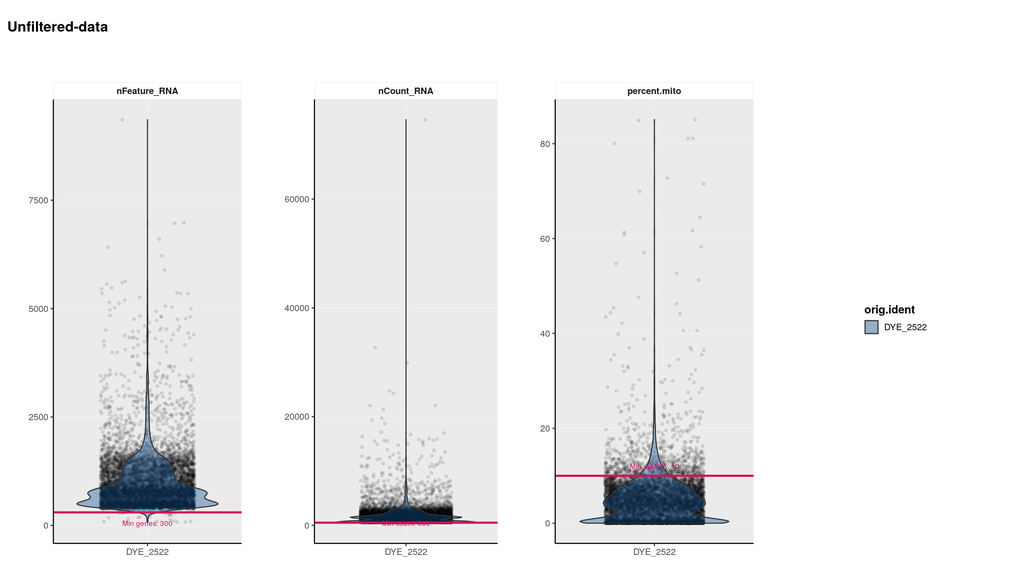

```r
fname <- paste0(samples_plots_dir, "/", sample_name[i], "_", "01", "_before_filter_vln_plot.png")
p <- print(create_vln_plot(seurat_obj = seurat_obj, grouping = grouping, min_genes = min_genes, min_count = min_count, title_name = "Unfiltered-data", palette = palette_df))
```

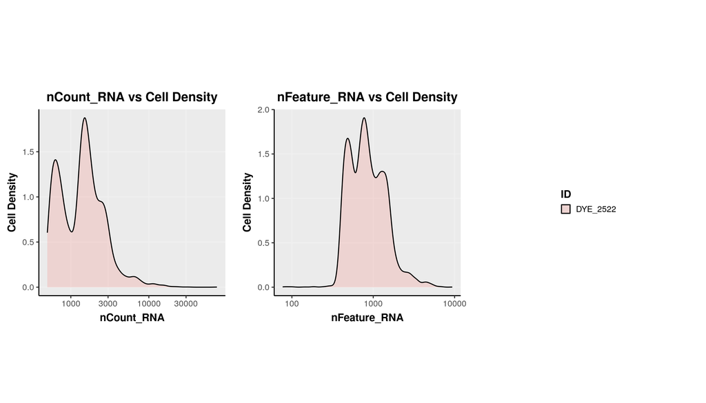

```r
ggsave(file = fname, p, width = 8, height = 6, device = "png")

Generate_QC_Plots_1(Seurat_obj = seurat_obj, Project_Path = seurat_qc_plots_dir, Figure_Total = "02", Analysis_Name = sample_name[i],
                    File_Name = "QC_Raw_Data", palette = gradient_palette_df)
```

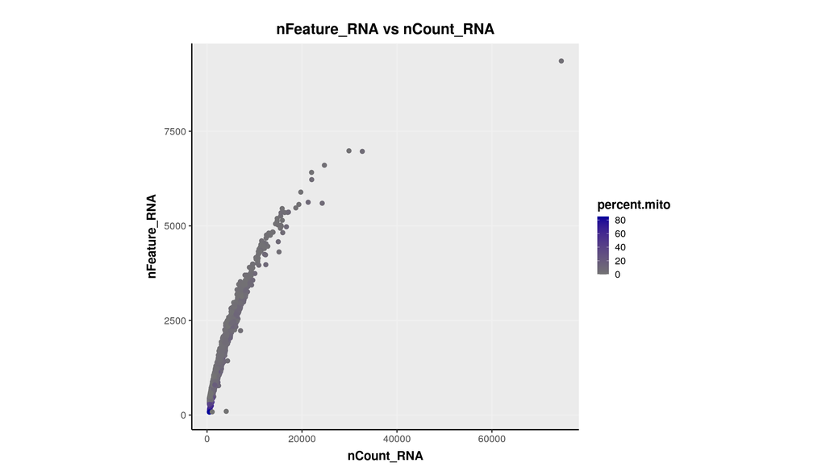

```r
Generate_QC_Plots_2(Seurat_obj = seurat_obj, Project_Path = seurat_qc_plots_dir, Figure_Total = "03", Analysis_Name = sample_name[i],
                    File_Name = "QC_Raw_Data", palette = gradient_palette_df)
```

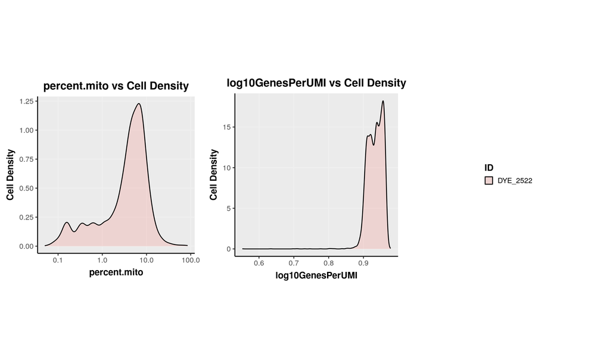

```r
Generate_QC_Plots_3(Seurat_obj = seurat_obj, Project_Path = seurat_qc_plots_dir, Figure_Total = "04", Analysis_Name = sample_name[i],
                    File_Name = "QC_Raw_Data", palette = gradient_palette_df)
```

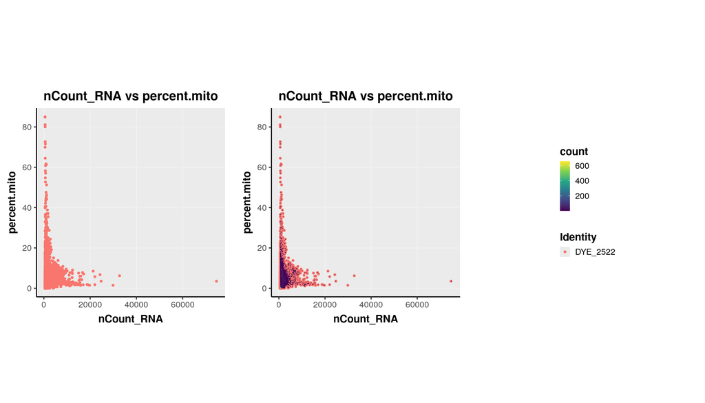

```r
Generate_QC_Plots_4(Seurat_obj = seurat_obj, Project_Path = seurat_qc_plots_dir, Figure_Total = "05", Analysis_Name = sample_name[i],
                    File_Name = "QC_Raw_Data", palette = gradient_palette_df)
```

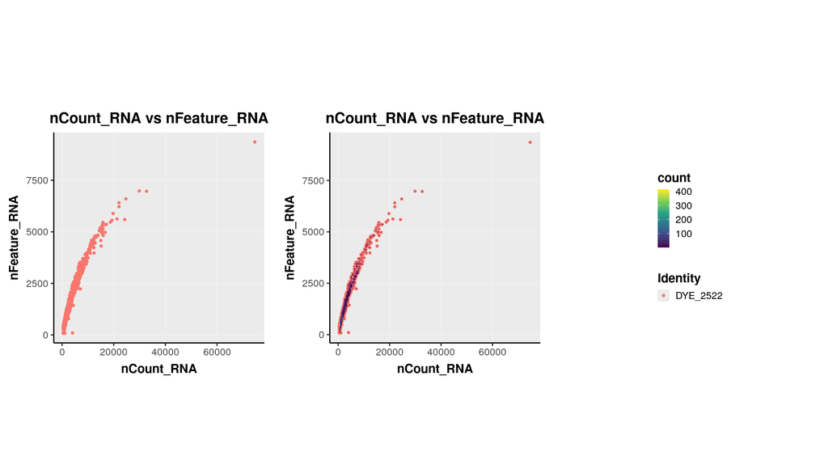

```r
Generate_QC_Plots_5(Seurat_obj = seurat_obj, Project_Path = seurat_qc_plots_dir, Figure_Total = "06", Analysis_Name = sample_name[i],
                    File_Name = "QC_Raw_Data", palette = gradient_palette_df)
```

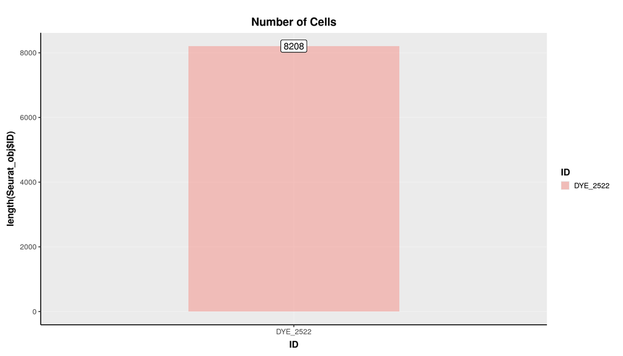

```r
Generate_QC_Plots_6(Seurat_obj = seurat_obj, Project_Path = seurat_qc_plots_dir, Figure_Total = "07", Analysis_Name = sample_name[i],
                    File_Name = "QC_Raw_Data", palette = gradient_palette_df)
```

# 6 QC steps for filtering low quality cells

Here, the user can select to implement the following strategies to remove low quality cells: - `step A` [miQC](https://bioconductor.org/packages/devel/bioc/vignettes/miQC/inst/doc/miQC.html) R package. miQC R package jointly models proportion of reads belonging to mitochondrial genes and number of unique genes detected. Cells with a high likelihood of being compromised (greater than 0.75) and cells that do not pass a minimum number of unique genes detected threshold of 200 will be removed from the counts matrix object. The cells at the very top of the graph are almost certainly compromised, most likely to have been derived from the distribution with fewer unique genes and higher baseline mitochondrial expression. In order to calculate the percent of reads in a cell that map to mitochondrial genes, we first need to establish which genes are mitochondrial. For genes listed as HGNC symbols, this is as simple as searching for genes starting with mt-. For other IDs, we recommend using a biomaRt query to map to chromosomal location and identify all mitochondrial genes. miQC is designed to be run with the Bioconductor package scater, which has a built-in function addPerCellQC to calculate basic QC metrics like number of unique genes detected per cell and total number of reads. When we pass in our list of mitochondrial genes, it will also calculate percent mitochondrial reads. The miQC model is based on the assumption that there are a non-trivial number of compromised cells in the dataset, which is not true in all datasets. If it is already known that the dataset is high-quality with a trivial number of compromised cells, we recommend that the user skip this step. If miQC does not identify any low quality cells, then the `step B` will automatically be used as for the filtering strategy. - `step B` `run_QC_default` function. This is split in two filtering steps. - `step 1`: Filter cells with low content of genes expressed and remove mtDNA from each library (as defined in the `params`). - `step 2`: `Find_Outlier_Thershold` function. This is an optional step (as defined in the `params`).

```r
cat("Run miQC for", sample_name[i], "\n")
```

```
## Run miQC for DYE_2522
```

```r
sce <- as.SingleCellExperiment(seurat_obj) # Create sce

# Indicates whether or not to use miQC
if (use_miQC == "YES"){
  print("We will use miQC.")
  set.seed(1234) # Set seed
  mt_genes <- grepl(sce$percent.mito, rownames(sce)) # Identify cells with mtDNA in the library
  feature_ctrls <- list(mito = rownames(sce)[mt_genes])
  sce <- addPerCellQC(sce, subsets = feature_ctrls)
  #head(colData(sce))
  print(plotMetrics(sce))
  seurat_obj <- run_miQC(sce) # Run QC function
  } else {
    print("We will QC with default parameters and/or the `Find_Outlier_Thershold` function.")
    seurat_obj <- run_QC_default(seurat_obj = seurat_obj)}
```

```
## [1] "We will QC with default parameters and/or the `Find_Outlier_Thershold` function."
## [1] "Use step 1 with default parameters for filtering and then use the `Find_Outlier_Thershold` function!"
## Step 1 data filter DYE_2522
## Step 2 data filter DYE_2522
```

# 7 Number of cells after filtering

```r
cat("Number of cells after filtering for sample", sample_name[i], ":", "\n")
```

```
## Number of cells after filtering for sample DYE_2522 :
```

```r
cells_so_after_filter_num <- print(ncol(seurat_obj)) # Number of cells after filter
```

```
## [1] 7049
```

# 8 Number of cells express a specific gene

We will calculate percentage of cells expressing each gene and their mean.

```r
cat("Number of cells express a specific gene for sample", sample_name[i], "\n")
```

```
## Number of cells express a specific gene for sample DYE_2522
```

```r
pct_cells <- apply(as.data.frame(seurat_obj@assays$RNA@counts), 1, function(x) (sum(x != 0))) / ncol(seurat_obj@assays$RNA@counts)
gene_means <- rowMeans(as.data.frame(seurat_obj@assays$RNA@counts))
p <- as.data.frame(cbind(pct_cells, gene_means)) %>%
  rownames_to_column("gene")

fname <- paste0(samples_plots_dir, "/", sample_name[i], "_", "08", "_cells_num_per_gene.png")
print(fname)
```

```
## [1] "/sc-rna-seq-snap-legacy-Victoria-Knockout-shareable/analyses/upstream-analysis/plots/02_Seurat_qc/DYE_2522/DYE_2522_08_cells_num_per_gene.png"
```

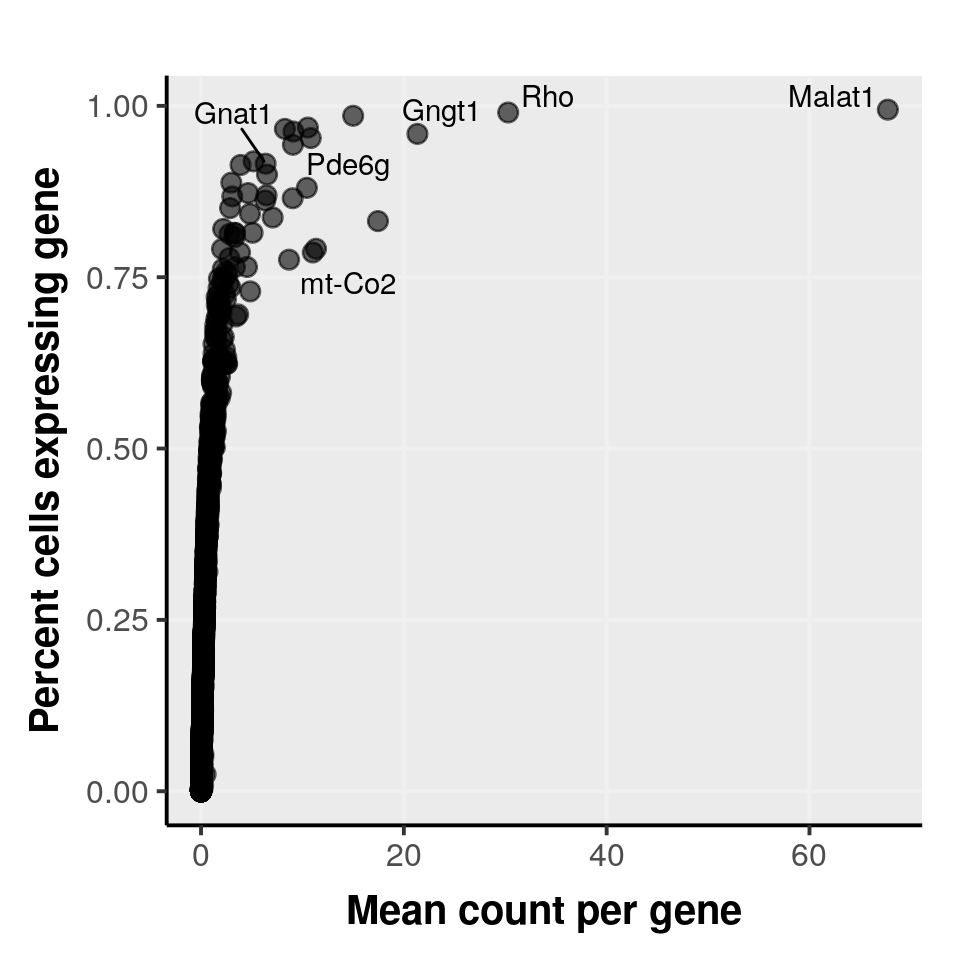

```r
set.seed(1234) # Set seed
plot <- print(ggplot(data = p, aes(x = gene_means, y = pct_cells, label = gene)) +
        theme_Publication () +
        geom_point(size = 3, alpha = 0.6) +
        xlab("Mean count per gene") +
        ylab("Percent cells expressing gene") +
        stat_dens2d_labels(geom = "text_repel", keep.fraction = 0.001))
```

```r
ggsave(filename = fname, plot, width = 5, height = 5, device = "png") # Save the plot
```

# 9 Number of expressed genes in the library

We will calculate the number of expressed genes in the library.

```r
cat("Number of expressed genes in the library for sample", sample_name[i], "\n")
```

```
## Number of expressed genes in the library for sample DYE_2522
```

```r
num_genes <- apply(as.data.frame(seurat_obj@assays$RNA@counts), 2, function(x) (sum(x != 0))) # number of expressed genes
libsize <- colSums(as.data.frame(seurat_obj@assays$RNA@counts))
l  <- as.data.frame(cbind(num_genes, libsize))

fname <- paste0(samples_plots_dir, "/", sample_name[i], "_", "09", "_genes_num_library.png")
print(fname)
```

```
## [1] "/sc-rna-seq-snap-legacy-Victoria-Knockout-shareable/analyses/upstream-analysis/plots/02_Seurat_qc/DYE_2522/DYE_2522_09_genes_num_library.png"
```

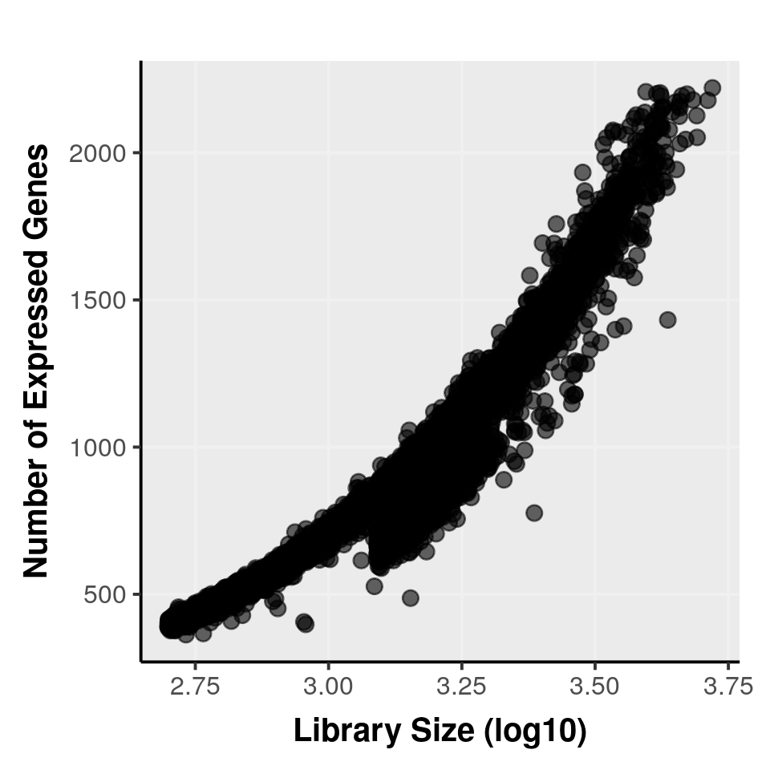

```r
set.seed(1234) # Set seed
plot <- print(ggplot(data = l, aes(x = log10(libsize), y = num_genes)) +
                theme_Publication () +
                geom_point(size = 3, alpha = 0.6) +
                xlab("Library Size (log10)") +
                ylab("Number of Expressed Genes"))
```

```r
ggsave(filename = fname, plot, width = 5, height = 5, device = "png") # Save the plot
```

# 10 Plot data after filtering

Next, we will plot distribution of the number of genes, UMI, and percent mitochondrial reads per cell after filtering any low-quality cells.

```r
cat("Generating QC plots for FILTERED data for sample", sample_name[i], "\n")
```

```
## Generating QC plots for FILTERED data for sample DYE_2522
```

```r
fname <- paste0(samples_plots_dir, "/", sample_name[i], "_", "10", "_after_filter_vln_plot.png")
print(fname)
```

```
## [1] "/sc-rna-seq-snap-legacy-Victoria-Knockout-shareable/analyses/upstream-analysis/plots/02_Seurat_qc/DYE_2522/DYE_2522_10_after_filter_vln_plot.png"
```

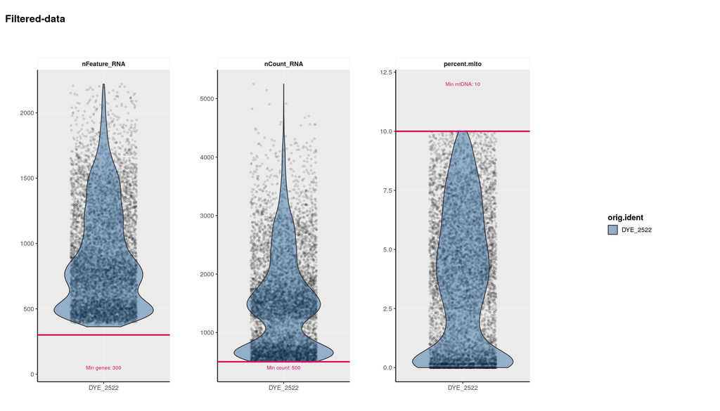

```r
p <- print(create_vln_plot(seurat_obj = seurat_obj, grouping = grouping, min_genes = min_genes, min_count = min_count, title_name = "Filtered-data", palette = palette_df))
```

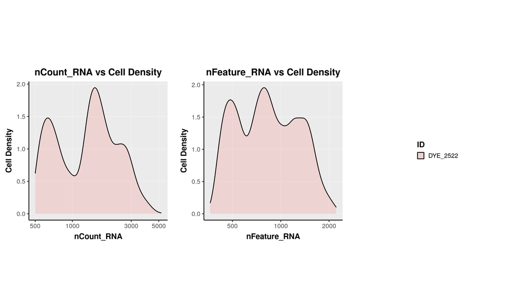

```r
ggsave(file = fname, p, width = 8, height = 6, device = "png")

Generate_QC_Plots_1(Seurat_obj = seurat_obj, Project_Path = seurat_qc_plots_dir, Figure_Total = "11", Analysis_Name = sample_name[i],
                    File_Name = "QC_Filtered_Data", palette = gradient_palette_df)
```

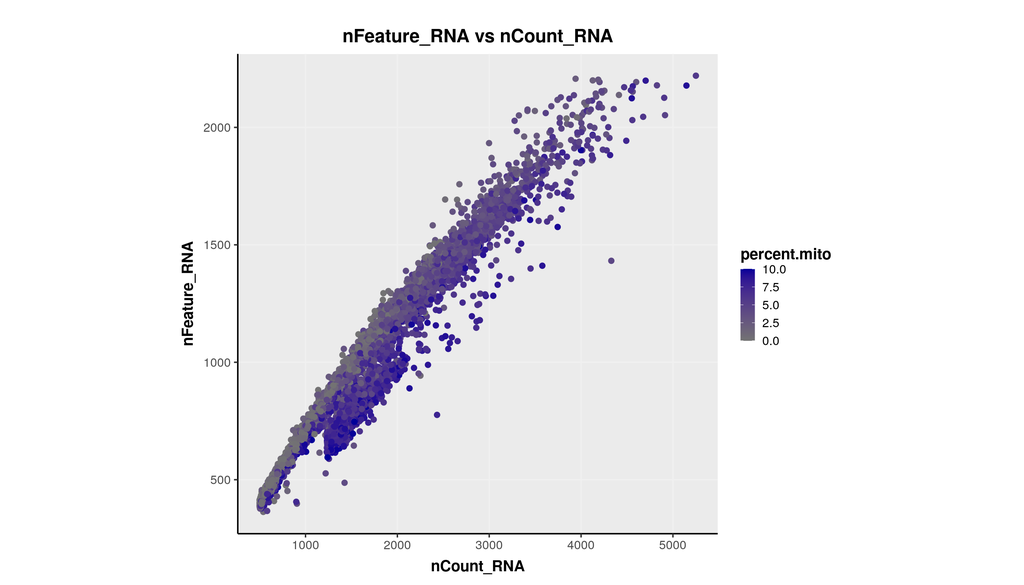

```r
Generate_QC_Plots_2(Seurat_obj = seurat_obj, Project_Path = seurat_qc_plots_dir, Figure_Total = "12", Analysis_Name = sample_name[i],
                    File_Name = "QC_Filtered_Data", palette = gradient_palette_df)
```

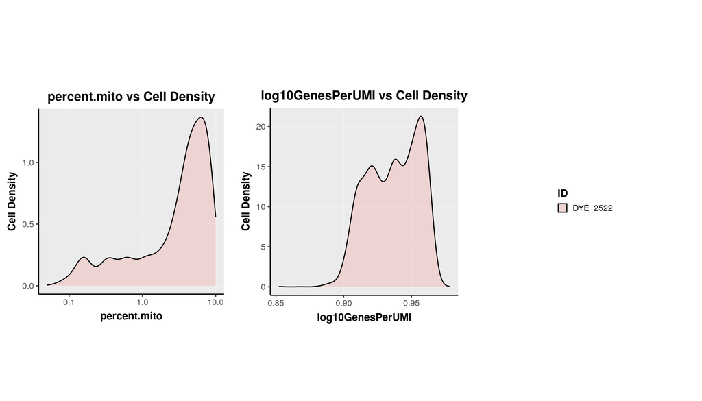

```r
Generate_QC_Plots_3(Seurat_obj = seurat_obj, Project_Path = seurat_qc_plots_dir, Figure_Total = "13", Analysis_Name = sample_name[i],
                    File_Name = "QC_Filtered_Data", palette = gradient_palette_df)
```

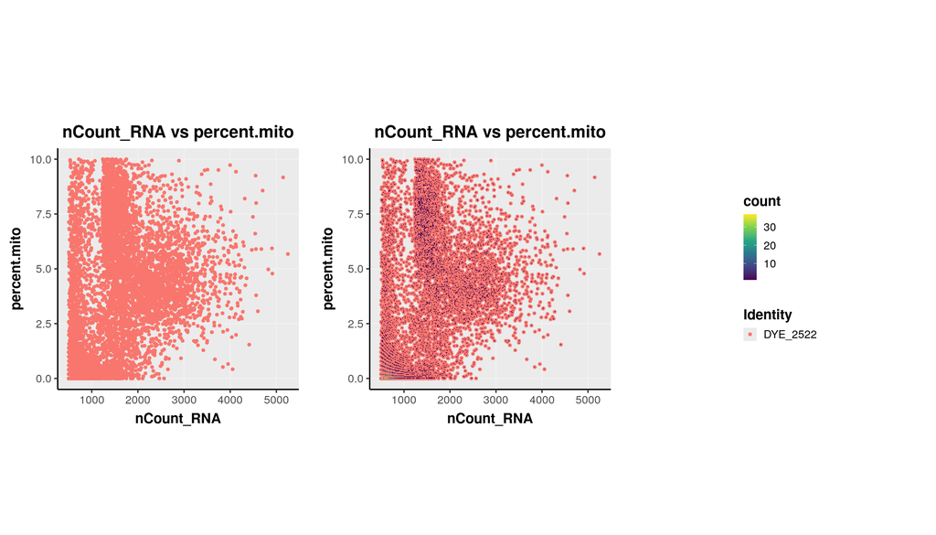

```r
Generate_QC_Plots_4(Seurat_obj = seurat_obj, Project_Path = seurat_qc_plots_dir, Figure_Total = "14", Analysis_Name = sample_name[i],
                    File_Name = "QC_Filtered_Data", palette = gradient_palette_df)
```

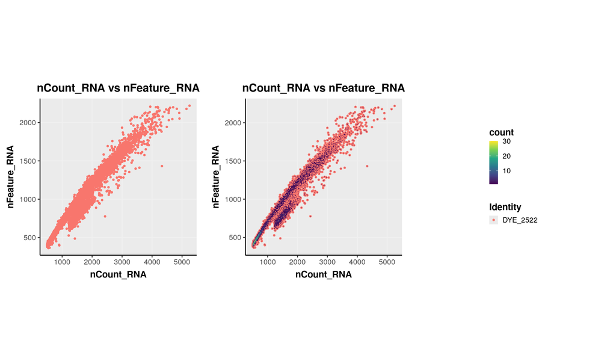

```r
Generate_QC_Plots_5(Seurat_obj = seurat_obj, Project_Path = seurat_qc_plots_dir, Figure_Total = "15", Analysis_Name = sample_name[i],
                    File_Name = "QC_Filtered_Data", palette = gradient_palette_df)
```

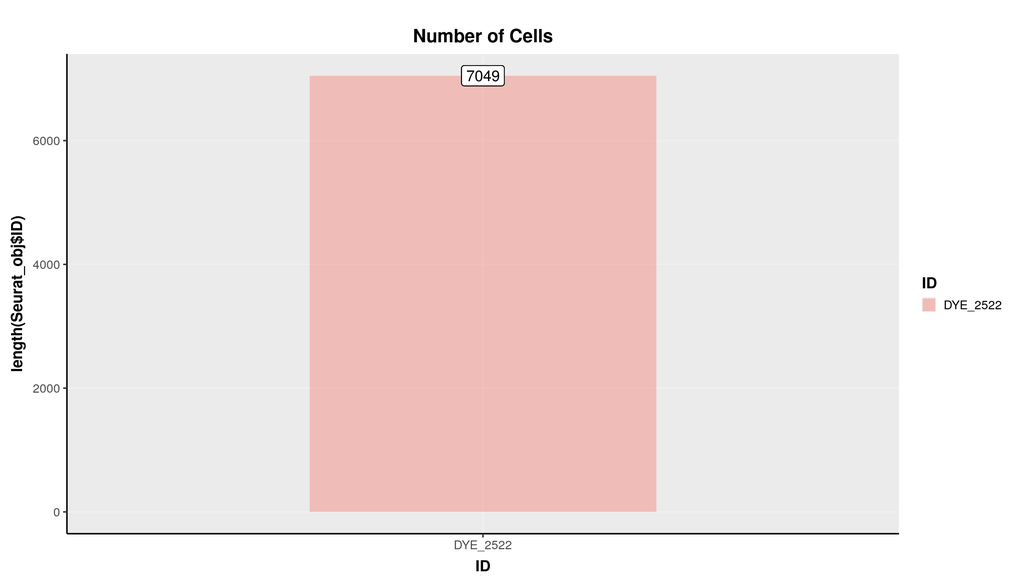

```r
Generate_QC_Plots_6(Seurat_obj = seurat_obj, Project_Path = seurat_qc_plots_dir, Figure_Total = "16", Analysis_Name = sample_name[i],
                    File_Name = "QC_Filtered_Data", palette = gradient_palette_df)
```

# 11 Process seurat object

The next steps include:

## 11.1 Normalization of the data

After removing unwanted cells from the dataset, the next step is to normalize the data. By default, we employ a global-scaling normalization method “LogNormalize” that normalizes the feature expression measurements for each cell by the total expression, multiplies this by a scale factor (10,000 by default), and log-transforms the result.

## 11.2 Identification of highly variable features (feature selection)

Next, we will calculate a subset of features that exhibit high cell-to-cell variation in the dataset (i.e, they are highly expressed in some cells, and lowly expressed in others). We and others have found that focusing on these genes in downstream analysis helps to highlight biological signal in single-cell datasets. By default, Seurat returns 2,000 features per dataset. These will be used in downstream analysis, like PCA.

## 11.3 Scaling the data

Next, we apply a linear transformation (‘scaling’) that is a standard pre-processing step prior to dimensional reduction techniques like PCA.

## 11.4 Perform linear dimensional reduction (PCA) and Run non-linear dimensional reduction (UMAP)

```
## Create and process seurat for sample DYE_2522
## Get cell cycle scores and then scale data
## Scale data
## [1] "We will NOT regress out for cell cycle and scale data!"
```

```
## Run PCA
## Run UMAP
## Plot the plots
##  [1] "Apoe"   "Glul"   "Pde6h"  "Clu"    "Opn1sw" "Arr3"   "Gngt2"  "Ttr"
##  [9] "Ptgds"  "Opn1mw"
## PC_ 1
## Positive:  Cadm2, Marchf1, Pcdh15, Cacnb2, Ush2a
## Negative:  Apoe, Cd9, Dkk3, Clu, Rlbp1
## PC_ 2
## Positive:  Cadm2, Apoe, Pcdh15, Marchf1, Dkk3
## Negative:  Gngt1, Smim40, Pde6g, Tma7, Ndufa4
## PC_ 3
## Positive:  Rlbp1, Cd9, Apoe, Fxyd1, Spc25
## Negative:  Sphkap, Cdh18, Cngb3, Gnat2, Pde6c
## PC_ 4
## Positive:  Cadm2, Rgs20, Marchf1, Cacnb2, Pcdh15
## Negative:  Cdh18, Sphkap, Gnat2, Cngb3, Pde6c
## PC_ 5
## Positive:  Gria4, Meg3, Nalf1, Ctnnd2, Nrxn3
## Negative:  Gnat2, Cngb3, Opn1mw, Pde6c, Arr3
```

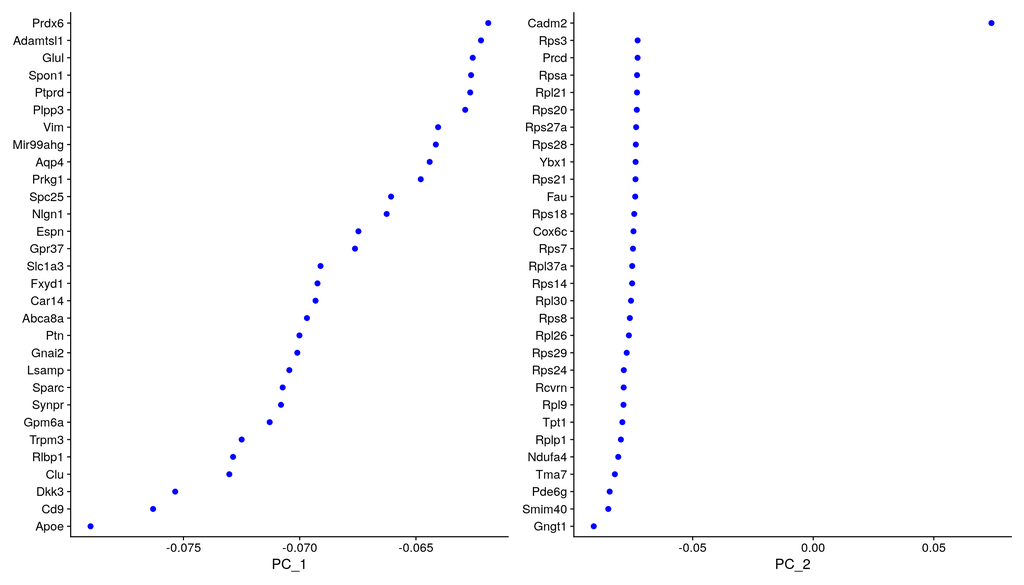

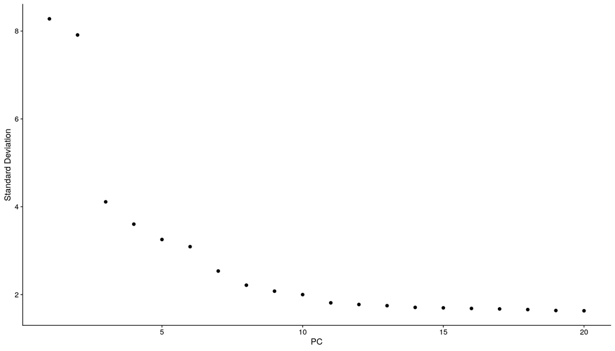

```
## Plot UMAP
## [1] "UMAPndim30nn30"
## [1] "/sc-rna-seq-snap-legacy-Victoria-Knockout-shareable/analyses/upstream-analysis/plots/02_Seurat_qc/DYE_2522/UMAPndim30nn30/"
```

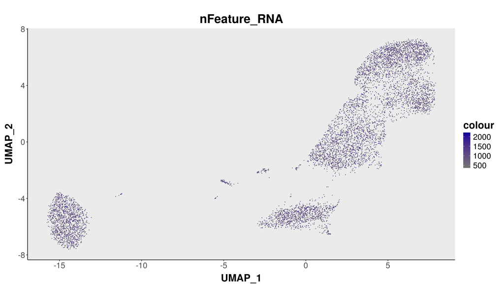

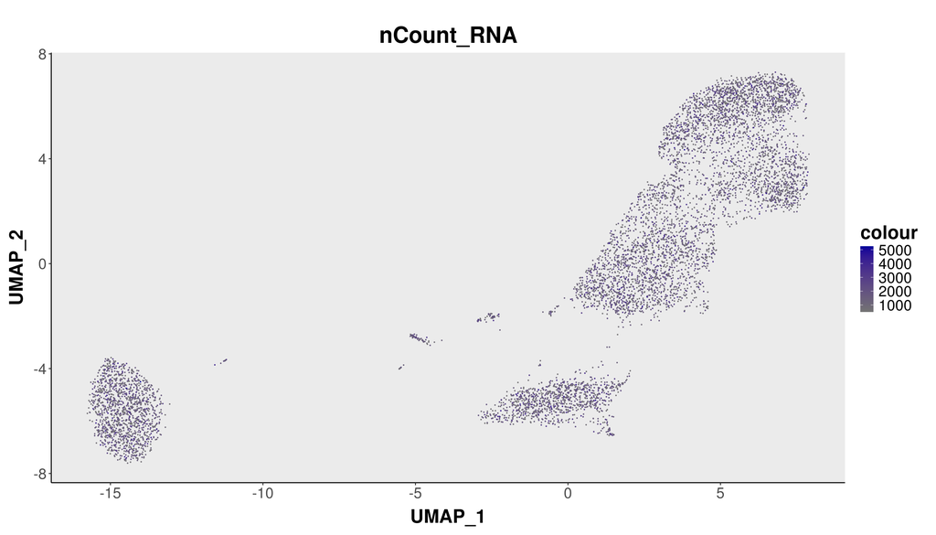

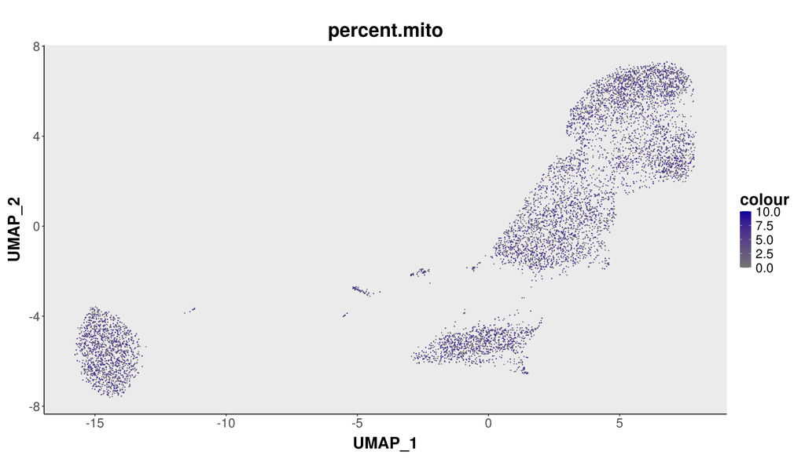

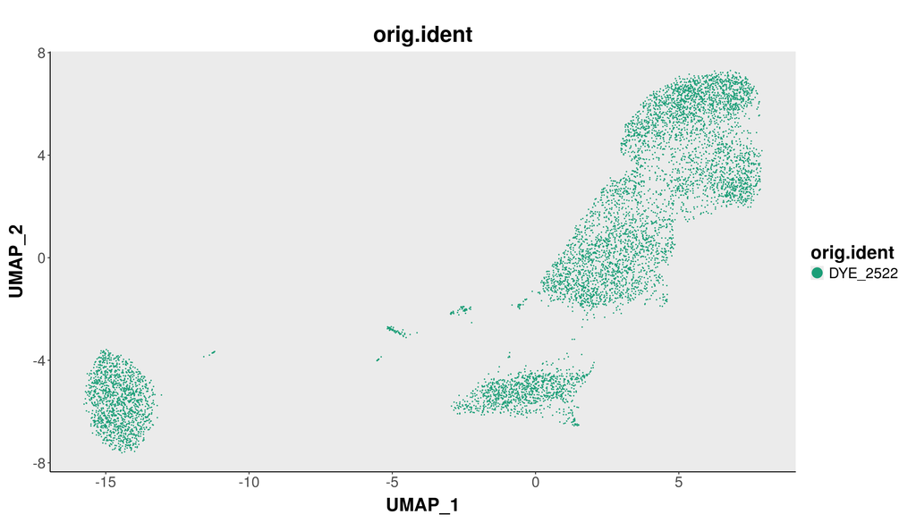

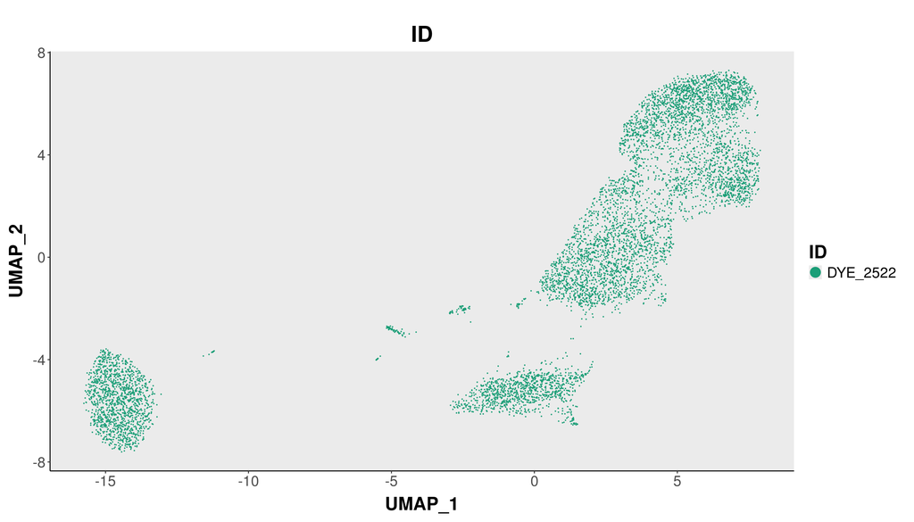

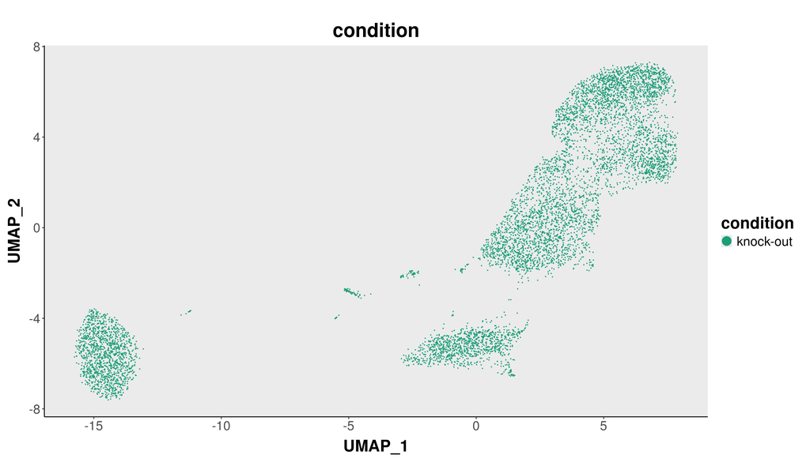

```
## [1] "Do NOT Print condition_split!"
## Returned Seurat object
## Save Seurat object for sample DYE_2522
```

```r
if (cells_so_after_filter_num >= 500) {

  # Only libraries with more than 500 cells will be kept for merging and integration purposes.
  # This value is a commonly used threshold for many single-cell RNA-seq studies as a minimum for obtaining reliable and meaningful analysis.

  print_message <- "we will proceed with processing of the seurat object and include the sample in the merged and integrated cohort for downstream analyses"
  cat("Create and process seurat for sample", sample_name[i], "\n")
  seurat_obj <- Process_Seurat(seurat_obj = seurat_obj, nfeatures_value = nfeatures_value, Genome = genome_name,
                               Regress_Cell_Cycle = Regress_Cell_Cycle_value, assay = assay, num_pcs = num_pcs,
                               prefix = prefix, num_dim = num_dim, num_neighbors = num_neighbors, results_dir = results_dir,
                               plots_output = samples_plots_dir, use_condition_split = use_condition_split,
                               condition1 = condition_value1, condition2 = condition_value2, condition3 = condition_value3,
                               print_pdf = print_pdf, PCA_Feature_List = PCA_Feature_List_value)

  cat("Save Seurat object for sample", sample_name[i], "\n")
  saveRDS(seurat_obj, file = paste0(results_dir, "/", "seurat_obj.rds")) # Save Seurat object

  } else {
    print_message <- "we will skip processing of the seurat object due to low number of cells (less than 500) and exclude the sample in the merged and integrated cohort for downstream analyses"
}
```

Here, we will proceed with processing of the seurat object and include the sample in the merged and integrated cohort for downstream analyses.